# Cartographie avec R

## Cartographie avec R, le package `cartography`

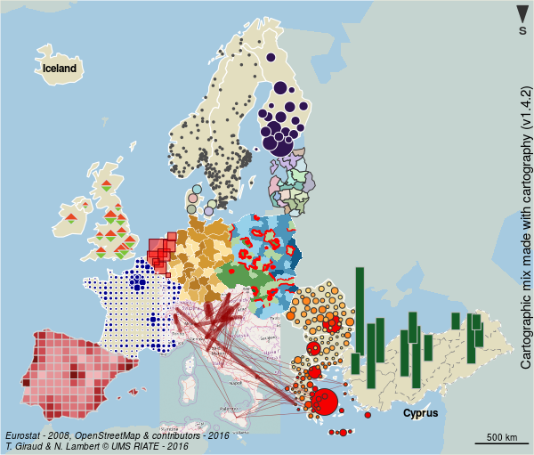

**[SEMIN-R](http://rug.mnhn.fr/semin-r/)**  
Museum National d’Histoire Naturelle | *Vendredi 16 juin 2017*

Timothée Giraud  
[UMS RIATE](http://riate.cnrs.fr)  
http://rgeomatic.hypotheses.org/

# Les fonctionnalités spatiales de R

## Les indispensables

3 packages sont incontournables

### rgdal

**Import/export d’objets spatiaux et gestion des projections cartographiques**

`rgdal` est une interface entre R et les librairies GDAL ([Geospatial Data Abstraction Library](http://www.gdal.org/)) et [PROJ4](https://github.com/OSGeo/proj.4).

```r
library("rgdal")
nuts3 <- readOGR(dsn = "data", layer = "nuts3", verbose = TRUE)
```

### sp

**Manipulation et affichage d’objets spatiaux**

`sp` fournit des classes et des methodes pour les données spatiales dans R.

```r
library("sp")
head(nuts3@data)
```

|  | id | birth_2008 | death_2008 | gdppps1999 | gdppps2008 | pop1999 | pop2008 |
| --- | --- | --- | --- | --- | --- | --- | --- |
| 0 | AT111 | 272 | 445 | 509 | 641 | 39148.91 | 37452 |
| 1 | AT112 | 1195 | 1480 | 2262 | 3272 | 137469.46 | 146383 |
| 2 | AT113 | 748 | 1142 | 1368 | 1783 | 100113.63 | 97350 |
| 3 | AT121 | 2480 | 2119 | 4091 | 5807 | 238591.26 | 241083 |
| 4 | AT122 | 2266 | 2577 | 4130 | 5774 | 244959.00 | 251838 |
| 5 | AT123 | 1363 | 1392 | 3098 | 4504 | 144269.11 | 147468 |

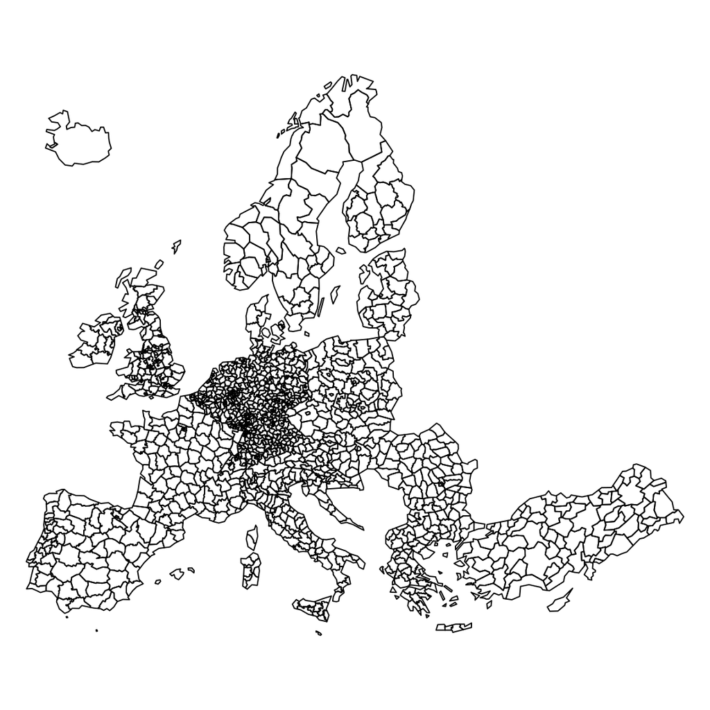

```r
plot(nuts3)
```

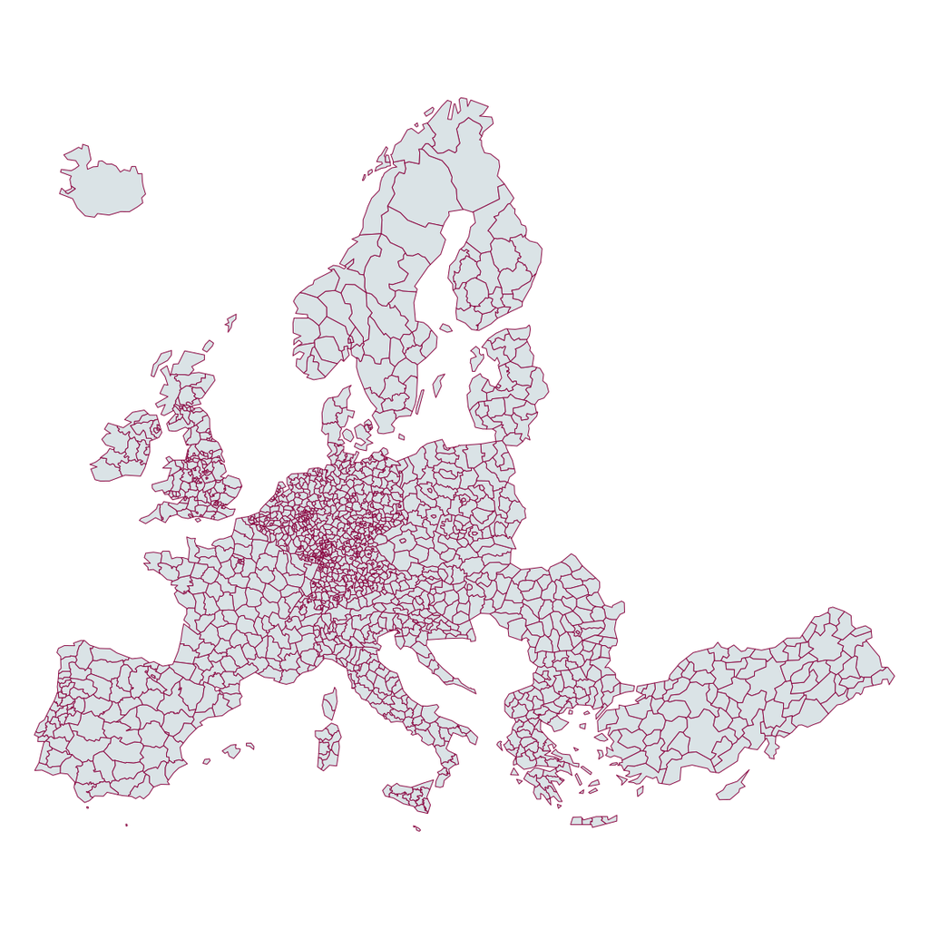

```r
plot(nuts3, col = "#DAE3E6", border = "#8A0641", lwd = 0.5)
```

### rgeos

**Géotraitements**

`rgeos` donne accès à la librairie d’opérations spatiales GEOS ([Geometry Engine - Open Source](http://trac.osgeo.org/geos/)) qui permet notamment d’effectuer les géotraitements suivants :

- Area / Perimeter
- Distances
- **Dissolve**
- **Buffer**
- Overlap / intersect / difference
- Contains / within
- Union
- …

#### Agrégation des polygones / dissolve

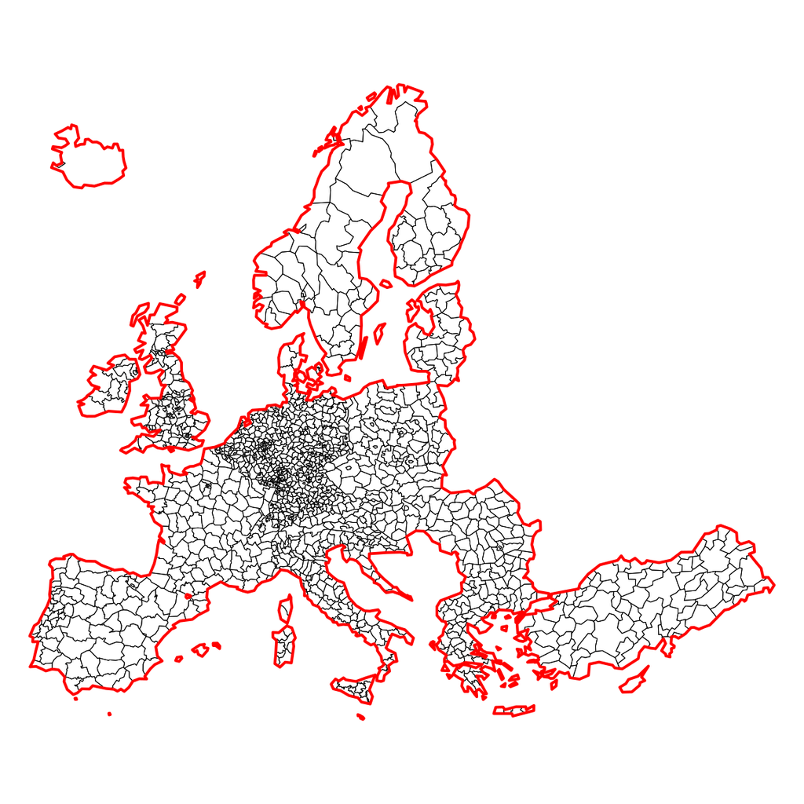

```r
library("rgeos")
europe <- gUnaryUnion(spgeom = nuts3)
plot(nuts3, lwd = 0.5)
plot(europe, lwd = 2, border = "red", add=T)
```

#### Création de zones tampons / buffer

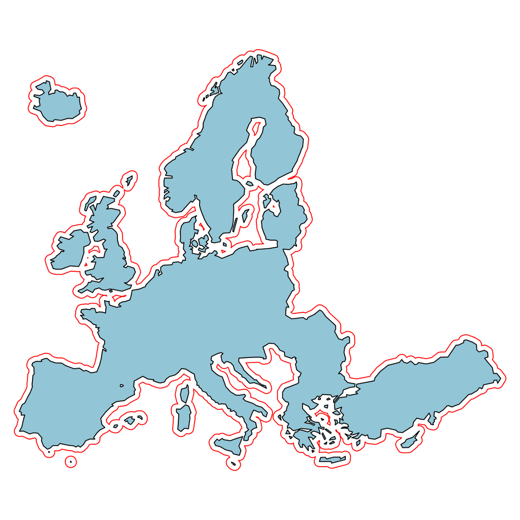

```r
library("rgeos")
europeBuffer <- gBuffer(spgeom = europe, width = 50000)
plot(europe, col = "#92C5D6")
plot(europeBuffer, add = T, border = "red")
```

## Le futur : le package sf

# Le package cartography

## Installation

- Version stable
- Version de développement
- Version avec sf

# Ressources

## *Package* `cartography`

**La page GitHub du *package* `cartography`**

C’est dans [ce dépôt GitHub](https://github.com/Groupe-ElementR/cartography) que se déroule le développement du *package* et que se tiennent les [discussions](https://github.com/Groupe-ElementR/cartography/issues) à son sujet.

**Billets de blogs, tutoriels, présentations**

[Demo codes in the R graph Gallery](http://www.r-graph-gallery.com/portfolio/maps/) (EN)  
[Create and integrate maps in your R workflow with the cartography package](http://rgeomatic.hypotheses.org/842) (EN)  
[De superbes cartes thématiques…](http://rgeomatic.hypotheses.org/1086)(FR)  
[Le package cartography a un an](http://rgeomatic.hypotheses.org/1016)(FR)  
[Cartographie avec R : le package cartography](http://rgeomatic.hypotheses.org/659) (FR)  
[R pour les cartographes](http://neocarto.hypotheses.org/1859) (FR)  
[Comment faire un carton avec R?](http://rgeomatic.hypotheses.org/category/cartography) (FR - *How to build inset maps*)  
[Tutoriel - Cartographie avec R](http://wukan.ums-riate.fr/r2016/) (FR)  
[Cartographie et traitement de l’information géographique avec R](http://wukan.ums-riate.fr/RUSS/RUSS_2016/) (FR)  
[R pour les cartographes : le package cartography](https://osgeo-fr.github.io/presentations_foss4gfr/2016/J1/R_Cartography_T_Giraud_FOSS4G-fr-2016/FOSS4G-fr-2016.html) (FR)

Le blog http://rgeomatic.hypotheses.org/

## *Package* `sf`

**La page GitHub du *package* `sf`**

C’est dans [ce dépôt GitHub](https://github.com/edzer/sfr) que se déroule le développement du *package* et que se tiennent les [discussions](https://github.com/edzer/sfr/issues?utf8=%E2%9C%93&q=is%3Aissue%20) à son sujet.

**Les ressources publiées par Edzer Pebesma**

Le créateur et *maintainer* de `sf` a publié un certain de nombre de vignettes et de billets autour du package.

- Vignettes
  - [Simple Features for R](https://cran.r-project.org/web/packages/sf/vignettes/sf1.html) Explication très détaillée des principes et du fonctionnement du package.
  - [Reading, Writing and Converting Simple Features](https://cran.r-project.org/web/packages/sf/vignettes/sf2.html) Comment importer et exporter des objets.
  - [Manipulating Simple Feature Geometries](https://cran.r-project.org/web/packages/sf/vignettes/sf3.html) Comment manipuler les objets `sf`, géotraitements, projections…
- Billets de blog
  - [Simple features for R](http://r-spatial.org/r/2016/02/15/simple-features-for-r.html)
  - [Simple features for R, part 2](http://r-spatial.org/r/2016/07/18/sf2.html)
  - [Simple features now on CRAN](http://r-spatial.org/r/2016/11/02/sfcran.html)
  - [sf - plot, graticule, transform, units, cast, is](http://r-spatial.org/r/2017/01/12/newssf.html)
- Migration de `sp` ver `sf`

  [Un tableau de migration de `sp` vers `sf`](https://github.com/edzer/sfr/wiki/migrating) pour passer de l’utilisation des packages `sp`, `rgeos` et `rgdal` à l’utilisation de `sf`.

**Billets de blogs / tutoriels**

- [Faire des cartes avec R - Introduction au package sf](https://github.com/riatelab/intro_sf) - Santiago Mora
- [Tidy spatial data in R: using dplyr, tidyr, and ggplot2 with sf](http://strimas.com/r/tidy-sf/) - Matt Strimas-Mackey
- [First Impressions From sf – The Simple Features R Package](https://geographicdatascience.com/2017/01/06/first-impressions-from-sf-the-simple-features-r-package/) - Geographic Data Science Lab
- [Spatial analysis pipelines with simple features in R](https://walkerke.github.io/2016/12/spatial-pipelines/) - Kyle Walker
- [Spatial analysis in R with the sf package](http://rhodyrstats.org/geospatial_with_sf/geospatial_with_sf.html) - rhodyRstats
- [Landscape Ecology with R:A tutorial with raster and sf](http://jwhollister.com/r_landscape_tutorial/tutorial.html) - Jeffrey W. Hollister
- [Mapping “France at night” with the new sf package](http://sharpsightlabs.com/blog/mapping-france-night/) - Sharp Sight Labs

## La cartographie

[figure not shown]

Béguin & Pumain (2003)

- Michelle Béguin et Denise Pumain. “La représentation des données géographiques, Statistique et cartographie.” (2003). Paris, Armand Colin, Coll. Cursus, 192p.

[figure not shown]

- Nicolas Lambert et Christine Zanin. “Manuel de cartographie: principes, méthodes, applications.” (2016). Paris, Armand Colin, Coll. Cursus, 224p.